# HW Week 4 Data 624

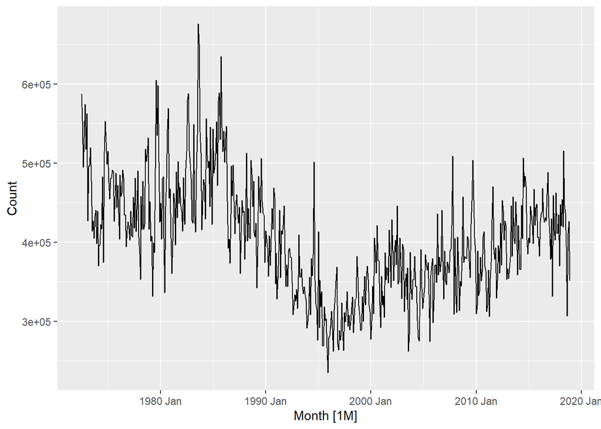

  ```r
  aus_livestock|>
    filter(Animal == 'Lambs' & State == 'New South Wales')|>
    autoplot(Count)
  ```

  The plot shows the seasonality and trend both.Therefore, Seasonal Naive Bays model best suit for this data.

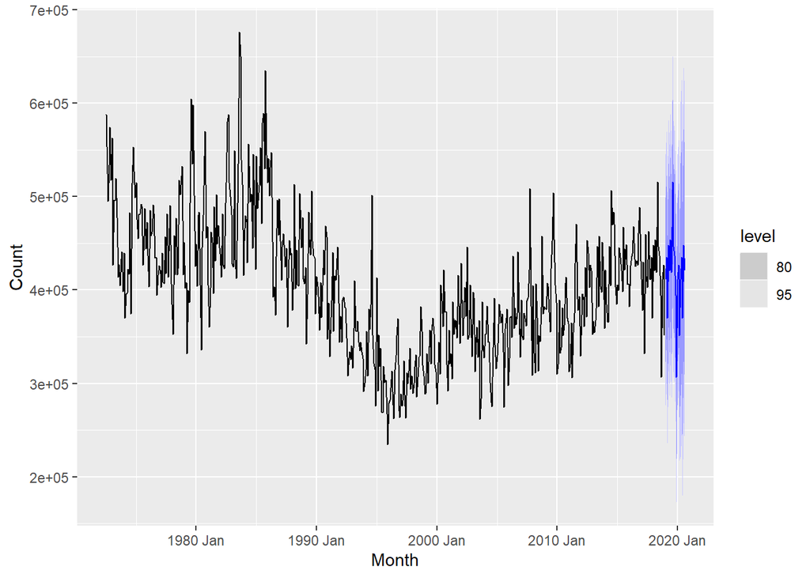

  ```r
  aus_livestock|>
  filter(Animal == 'Lambs' & State == 'New South Wales')|>
  model(snaive = SNAIVE(Count ~ lag(15)))|>
  forecast(h=20)|>
  autoplot(aus_livestock)
  ```

- Household wealth (hh_budget)

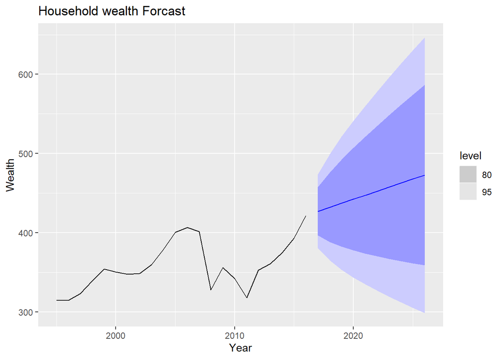

  ```r
  hh_budget %>%
    filter(Country =='Australia') |>
    model(Drift = RW(Wealth ~ drift())) |>
    forecast(h = 10) |>
    autoplot(hh_budget) +
      labs(title = "Household wealth Forcast")
  ```

- Australian takeaway food turnover (aus_retail).

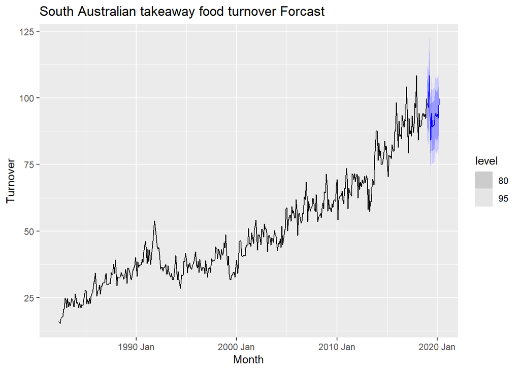

  ```r
  aus_retail %>%
    filter(State == "South Australia",
           Industry == 'Takeaway food services') %>%
    model(SNAIVE(Turnover ~ lag(15))) %>%
    forecast(h = 15) %>%
    autoplot(aus_retail) +
      labs(title = "South Australian takeaway food turnover Forcast")
  ```

## Problem 5.2

**Use the facebook stock price (data set gafa_stock) to do the following:**

1. Produce a time plot of the series.

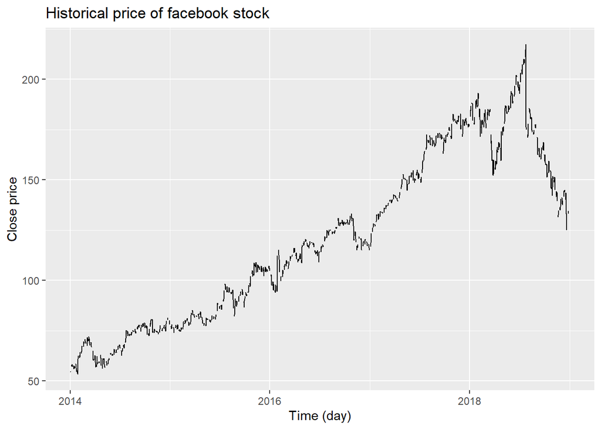

   ```r
   fb_df <- gafa_stock|>
     filter(Symbol == 'FB')|>
     filter(!is.na(Close))|>
     as_tsibble(key = Symbol, index = Date, regular = TRUE)|>
     fill_gaps()
   autoplot(fb_df, Close)+
     labs(title = "Historical price of facebook stock",
     x = 'Time (day)',
     y= 'Close price')
   ```

2. Produce forecasts using the drift method and plot them.

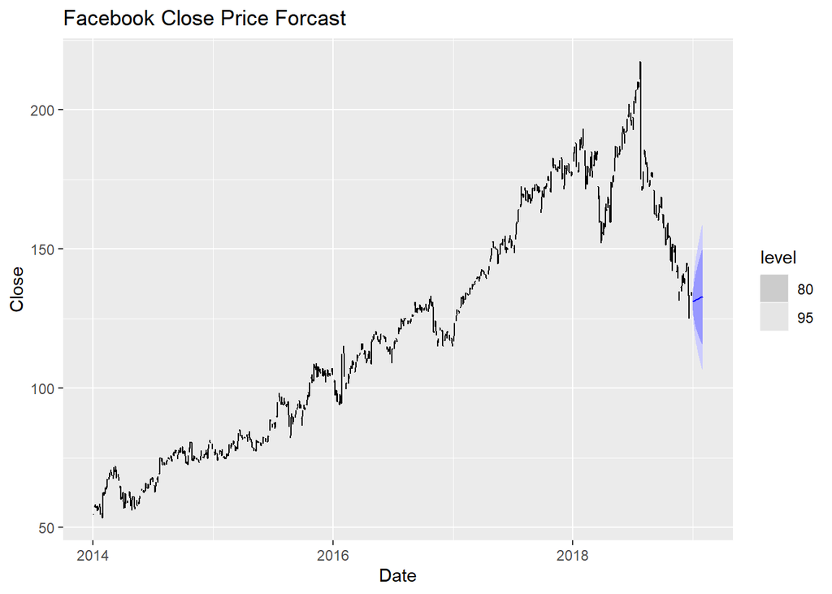

   ```r
   fb_df %>%
   model(Drift = RW(Close ~ drift())) %>%
     forecast(h = 30) %>%
     autoplot(fb_df) +
   labs(title = "Facebook Close Price Forcast")
   ```

3. Show that the forecasts are identical to extending the line drawn between the first and last observations.

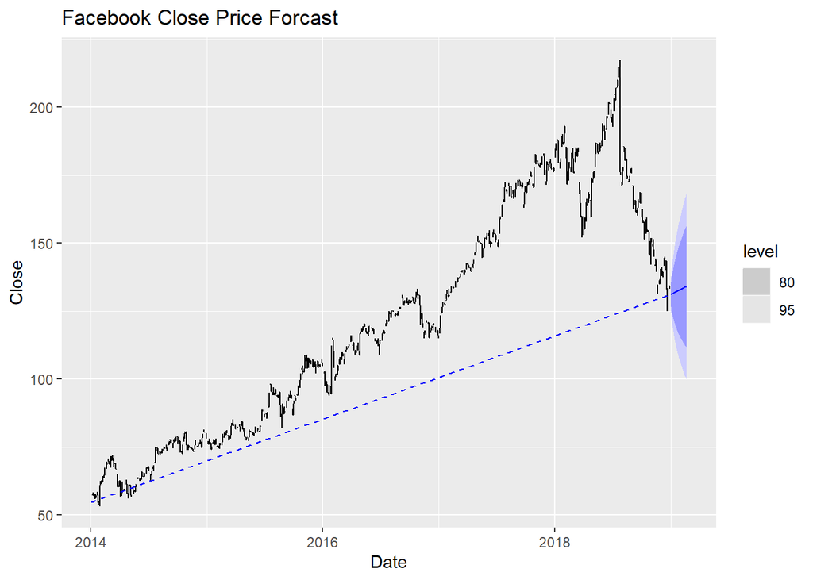

```r
df_line <- data.frame(x1 = as.Date('2014-01-02'), x2 = as.Date('2018-12-31'), y1= 54.71, y2=131.09)
fb_df %>%
model(Drift = RW(Close ~ drift())) %>%
  forecast(h = 50) %>%
  autoplot(fb_df) +
    labs(title = "Facebook Close Price Forcast")+
  geom_segment(data = df_line, aes(x=x1, y=y1, xend = x2, yend = y2), colour = 'blue', linetype ='dashed')
```

4. Try using some of the other benchmark functions to forecast the same data set. Which do you think is best? Why

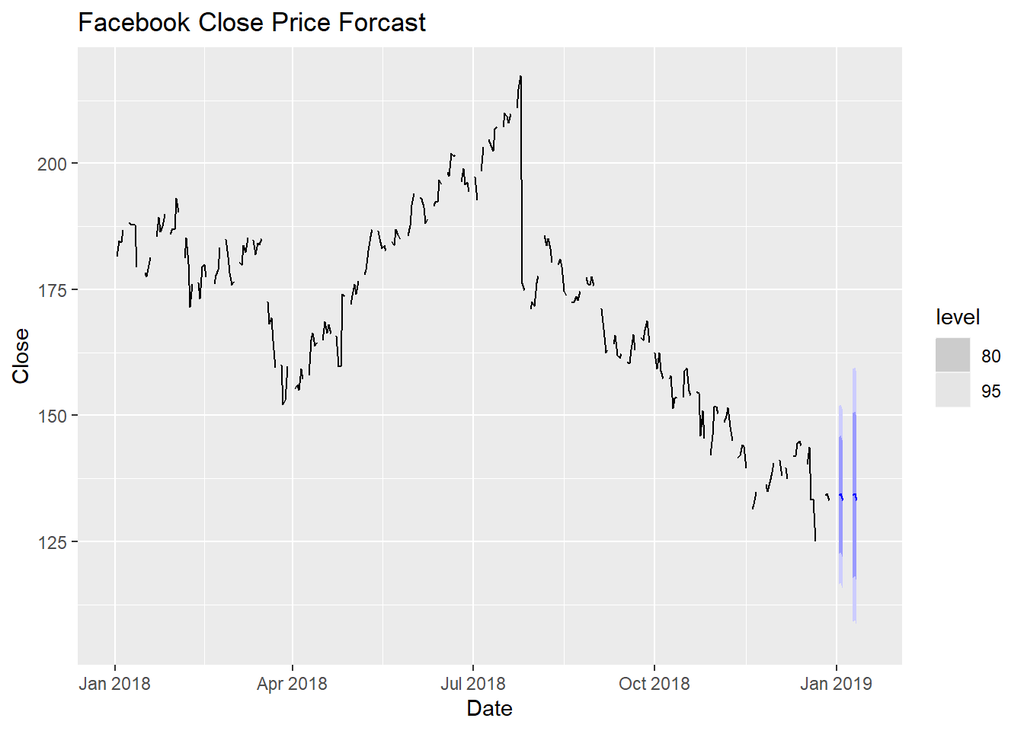

```r
fb_model<- fb_df |>
  filter_index("2018-01-01" ~ "2019-01-01")|>
      fill_gaps(Close)
fb_model|>
  model(Drift = SNAIVE(Close, lag('10 day'))) |>
  forecast(h = 15)|>
  autoplot(fb_model) +
    labs(title = "Facebook Close Price Forcast")
```